# 30531 Problem Set 5

Ying Cai

2018-11-01

**Front matter**

This submission is my work alone and complies with the 30531 integrity policy.

Add your initials to indicate your agreement: *YC*

```r
# LOAD LIBRARIES HERE
library(tidyverse)
library(ggplot2)
library(readxl)
library(testthat)
```

# 1 Exercises

## 1.1 Tidy data with spread() and gather()

1. (1)table 1 : It contains four variables: country, year, cases and population. There are six observations in it.  
   (2)table 2 : It contains four variables: country, year, type and count. There are twelve observations in it.  
   (3)table 3 : It contains three variables: country, year and rate. There are six observations in it.  
   (4)table 4a : Two values of year, 1999 and 2000, are placed in columns. The values of cases are positioned corresponding to the countries in row and years in column.  
   (5)table 4b : Two values of year, 1999 and 2000, are placed in columns. The values of population are positioned corresponding to the countries in row and years in column.

```r
print(table1)
```

```
## # A tibble: 6 x 4
##   country      year  cases population
##   <chr>       <int>  <int>      <int>
## 1 Afghanistan  1999    745   19987071
## 2 Afghanistan  2000   2666   20595360
## 3 Brazil       1999  37737  172006362
## 4 Brazil       2000  80488  174504898
## 5 China        1999 212258 1272915272
## 6 China        2000 213766 1280428583
```

```r
print(table2)
```

```
## # A tibble: 12 x 4
##    country      year type            count
##    <chr>       <int> <chr>           <int>
##  1 Afghanistan  1999 cases             745
##  2 Afghanistan  1999 population   19987071
##  3 Afghanistan  2000 cases            2666
##  4 Afghanistan  2000 population   20595360
##  5 Brazil       1999 cases           37737
##  6 Brazil       1999 population  172006362
##  7 Brazil       2000 cases           80488
##  8 Brazil       2000 population  174504898
##  9 China        1999 cases          212258
## 10 China        1999 population 1272915272
## 11 China        2000 cases          213766
## 12 China        2000 population 1280428583
```

```r
print(table3)
```

```
## # A tibble: 6 x 3
##   country      year rate
## * <chr>       <int> <chr>
## 1 Afghanistan  1999 745/19987071
## 2 Afghanistan  2000 2666/20595360
## 3 Brazil       1999 37737/172006362
## 4 Brazil       2000 80488/174504898
## 5 China        1999 212258/1272915272
## 6 China        2000 213766/1280428583
```

```r
print(table4a)
```

```
## # A tibble: 3 x 3
##   country     `1999` `2000`
## * <chr>        <int>  <int>
## 1 Afghanistan    745   2666
## 2 Brazil       37737  80488
## 3 China       212258 213766
```

```r
print(table4b)
```

```
## # A tibble: 3 x 3
##   country         `1999`     `2000`
## * <chr>            <int>      <int>
## 1 Afghanistan   19987071   20595360
## 2 Brazil       172006362  174504898
## 3 China       1272915272 1280428583
```

2. The table2 is harder and table4a + table4b is slightlly easier to work with beacuse the cells in it are easier to be positioned and extracted. In general, however, both representation are not very easy to cope with because both of them don’t comply with the rules of a tidy dataset: variables are in columns and values are in cells.

```r
#table2
cases <-
  table2 %>%
  filter(type == "cases") %>%
  rename(cases = count)
pop <-
  table2 %>%
  filter(type == "population") %>%
  rename(population = count)
t_rate <-
  cases %>%
  mutate(pop = pop[[4]],
         rate = (cases / pop) * 10000) %>%
  select(country, year, rate) %>%
  mutate(type = "rate") %>%
  rename(count = rate)
(t_rate <- bind_rows(table2, t_rate) %>% arrange(country, year, type, count))
```

```
## # A tibble: 18 x 4
##    country      year type         count
##    <chr>       <int> <chr>        <dbl>
##  1 Afghanistan  1999 cases      7.45e+2
##  2 Afghanistan  1999 population 2.00e+7
##  3 Afghanistan  1999 rate       3.73e-1
##  4 Afghanistan  2000 cases      2.67e+3
##  5 Afghanistan  2000 population 2.06e+7
##  6 Afghanistan  2000 rate       1.29e+0
##  7 Brazil       1999 cases      3.77e+4
##  8 Brazil       1999 population 1.72e+8
##  9 Brazil       1999 rate       2.19e+0
## 10 Brazil       2000 cases      8.05e+4
## 11 Brazil       2000 population 1.75e+8
## 12 Brazil       2000 rate       4.61e+0
## 13 China        1999 cases      2.12e+5
## 14 China        1999 population 1.27e+9
## 15 China        1999 rate       1.67e+0
## 16 China        2000 cases      2.14e+5
## 17 China        2000 population 1.28e+9
## 18 China        2000 rate       1.67e+0
```

```r
#table4a + table4b
t_rate <-
  table4a %>%
  mutate(rate_99 = (`1999` / table4b$`1999`) * 10000,
         rate_00 = (`2000` / table4b$`2000`) * 10000) %>%
  select(country, rate_99, rate_00) %>%
  rename(`1999` = rate_99, `2000` = rate_00)
t_rate
```

```
## # A tibble: 3 x 3
##   country     `1999` `2000`
##   <chr>        <dbl>  <dbl>
## 1 Afghanistan  0.373   1.29
## 2 Brazil       2.19    4.61
## 3 China        1.67    1.67
```

3. We need to filter the count values of “cases” first.

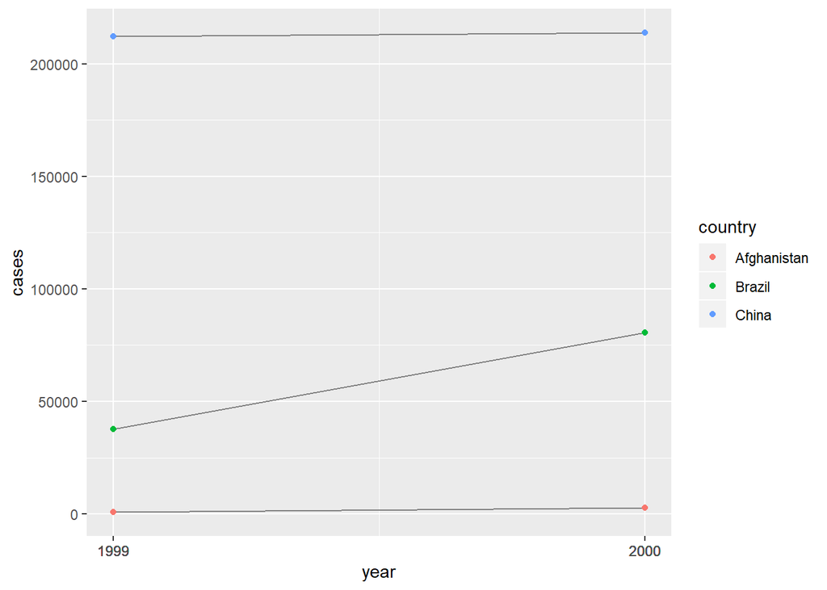

```r
ggplot(filter(table2, type == "cases"), aes(year, count)) +
  geom_line(aes(group = country), color = "grey50") +
  geom_point(aes(color = country)) +
  scale_x_continuous(breaks = table2$year) +
  labs(y = "cases")
```

4. The functions spread() and gather() are not perfectly symmetrical because the type of variables might change after this process. When variables are gathered, they are always converted into chr. In this example, the type of variable “year” is transformed from dbl to chr.
5. This code fails because 1999 and 2000 are treated as numbers, which makes them not able to be recognized as the column names. To fix it, we need to put them in `` to convert them into characters.

```r
#error
table4a %>% gather(1999, 2000, key = "year", value = "cases")
```

```r
#modification
table4a %>% gather(`1999`, `2000`, key = "year", value = "cases")
```

```
## # A tibble: 6 x 3
##   country     year   cases
##   <chr>       <chr>  <int>
## 1 Afghanistan 1999     745
## 2 Brazil      1999   37737
## 3 China       1999  212258
## 4 Afghanistan 2000    2666
## 5 Brazil      2000   80488
## 6 China       2000  213766
```

6. Spreading this tibble fails because there are duplicate values as identifiers in rows 1 and row 3.

```r
#tribble
people <- tribble(
  ~name, ~key, ~value,
  #-----------------|--------|-----
  "Phillip Woods", "age", 45,
  "Phillip Woods", "height", 186,
  "Phillip Woods", "age", 50,
  "Jessica Cordero", "age", 37,
  "Jessica Cordero", "height", 156
)
```

```r
#error
spread(people, key = key, value = value)
```

```r
#modification
people <- tribble(
  ~name, ~key, ~value, ~id,
  #-----------------|--------|-----
  "Phillip Woods", "age", 45, 1,
  "Phillip Woods", "height", 186, 1,
  "Phillip Woods", "age", 50, 2,
  "Jessica Cordero", "age", 37, 3,
  "Jessica Cordero", "height", 156, 3,
)
spread(people, key = key, value = value)
```

```
## # A tibble: 3 x 4
##   name               id   age height
##   <chr>           <dbl> <dbl>  <dbl>
## 1 Jessica Cordero     3    37    156
## 2 Phillip Woods       1    45    186
## 3 Phillip Woods       2    50     NA
```

7. We need to gather it and the variables are “pregnant”, “gender” and “count”

```r
#original tibble
preg <- tribble( ~pregnant, ~male, ~female, "yes", NA, 10, "no", 20, 12 )
#tidy tibble
preg_tidy <- preg %>% gather(key = gender, value = count, -pregnant)
preg_tidy
```

```
## # A tibble: 4 x 3
##   pregnant gender count
##   <chr>    <chr>  <dbl>
## 1 yes      male      NA
## 2 no       male      20
## 3 yes      female    10
## 4 no       female    12
```

8. The argument extra in separate() controls what happens when there are too many pieces. It contains three valid options: (1)“warn” (the default): emit a warning and drop extra values. (2)“drop”: drop any extra values without a warning. (3)“merge”: only splits at most length(into) times.  
   The argument fill in separate() controls what happens when there are not enough pieces. It contains three valid options: (1)“warn” (the default): emit a warning and fill from the right. (2)“right”: fill with missing values on the right. (3)“left”: fill with missing values on the left.

```r
#original tibble
tibble(x = c("a,b,c", "d,e,f,g", "h,i,j")) %>%
  separate(x, c("one", "two", "three"))
```

```
## Warning: Expected 3 pieces. Additional pieces discarded in 1 rows [2].
```

```
## # A tibble: 3 x 3
##   one   two   three
##   <chr> <chr> <chr>
## 1 a     b     c
## 2 d     e     f
## 3 h     i     j
```

```r
tibble(x = c("a,b,c", "d,e", "f,g,i")) %>%
  separate(x, c("one", "two", "three"))
```

```
## # A tibble: 3 x 3
##   one   two   three
##   <chr> <chr> <chr>
## 1 a     b     c
## 2 d     e     <NA>
## 3 f     g     i
```

```r
#using the argument extra
tibble(x = c("a,b,c", "d,e,f,g", "h,i,j")) %>%
  separate(x, c("one", "two", "three"), extra = "drop")
```

```
## # A tibble: 3 x 3
##   one   two   three
##   <chr> <chr> <chr>
## 1 a     b     c
## 2 d     e     f
## 3 h     i     j
```

```r
#using the argument fill
tibble(x = c("a,b,c", "d,e", "f,g,i")) %>%
  separate(x, c("one", "two", "three"), fill = "right")
```

```
## # A tibble: 3 x 3
##   one   two   three
##   <chr> <chr> <chr>
## 1 a     b     c
## 2 d     e     <NA>
## 3 f     g     i
```

## 1.2 tidying case study (12.6)

```r
# tidy the dataset
who <- tidyr::who
who_tidy <-
  who %>%
  gather(key, value, new_sp_m014:newrel_f65) %>%
  mutate(key = stringr::str_replace(key, "newrel", "new_rel")) %>%
  separate(key, c("new", "var", "sexage")) %>%
  select(-new) %>%
  separate(sexage, c("sex", "age"), sep = 1)
#https://r4ds.had.co.nz/tidy-data.html

# check implicit missing values
check_mis<- who_tidy %>% complete(var, year, country, sex, age)
sum(is.na(check_mis$value))
```

```
## [1] 340930
```

```r
#check country-year pairs
ctry_year_mis <-
  who_tidy %>%
  group_by(country, year)  %>%
  mutate(mis = is.na(value)) %>%
  select(country, year, mis) %>%
  distinct() %>%
  group_by(country, year) %>%
  filter(mis==TRUE)
```

2. Zero probably means there is no cases while NA suggests the data of cases is missing.
3. If we neglect the mutate() step, the separation of columns names starting with “newrel_” will fail because the positions of “_" in columns starting with “new_sp” and “newrel_” are different.

```r
#skip the mutate() step
who_skip_mut <-
  who %>%
  gather(key, value, new_sp_m014:newrel_f65) %>%
  separate(key, c("new", "var", "sexage"), sep = "_") %>%
  select(-new, -iso2, -iso3) %>%
  separate(sexage, c("sex", "age"), sep = 1)
```

4. Because country, iso2 and iso3 all identify the same row, the two of them are rundant.

```r
distinct_ctry <-
  who_tidy %>%
  select(country, iso2, iso3) %>%
  distinct()

distinct_ctry %>% group_by(country) %>% filter(n()>1)
```

```
## # A tibble: 0 x 3
## # Groups:   country [0]
## # ... with 3 variables: country <chr>, iso2 <chr>, iso3 <chr>
```

5. The total number of cases of TB cases is as following.

```r
#1
total_num <-
  who_tidy %>%
  group_by(country, year, sex) %>%
  summarise(total_num = sum(value, na.rm = TRUE)) %>%
  filter(year >= 1997)

print(total_num)
```

```
## # A tibble: 7,272 x 4
## # Groups:   country, year [3,636]
##    country      year sex   total_num
##    <chr>       <int> <chr>     <int>
##  1 Afghanistan  1997 f           102
##  2 Afghanistan  1997 m            26
##  3 Afghanistan  1998 f          1207
##  4 Afghanistan  1998 m           571
##  5 Afghanistan  1999 f           517
##  6 Afghanistan  1999 m           228
##  7 Afghanistan  2000 f          1751
##  8 Afghanistan  2000 m           915
##  9 Afghanistan  2001 f          3062
## 10 Afghanistan  2001 m          1577
## # ... with 7,262 more rows
```

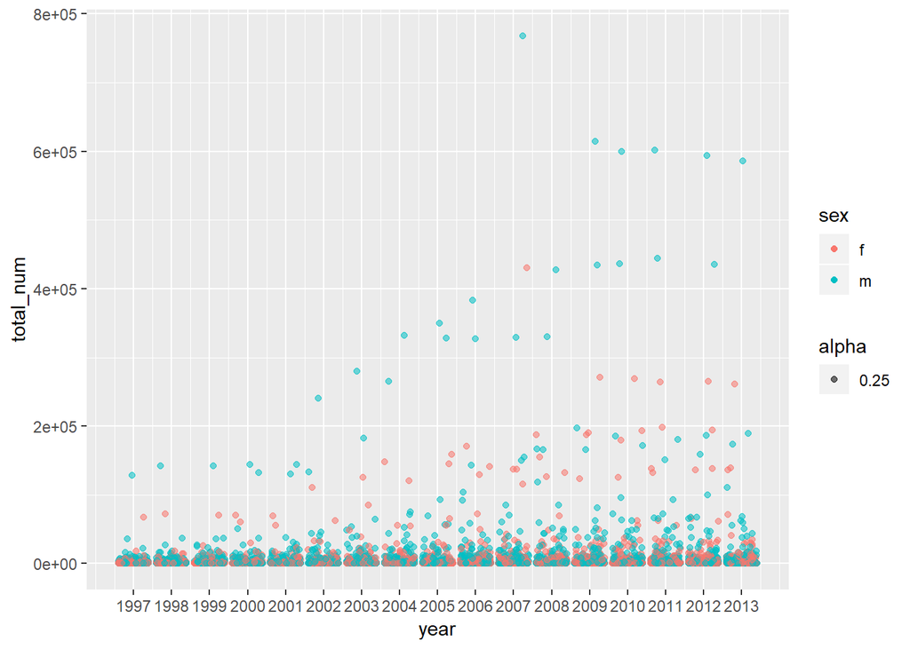

```r
total_num %>%
  ggplot(aes(x = year, y = total_num, color = sex, alpha = 0.25))+
  geom_jitter()+
  scale_x_continuous(breaks = 1997:2013)
```

2. Because raw values only give the information of absolute numbers of cases, the link between sex and TB cases is not clearly demonstrated in raw values.

```r
ratio_sex <-
  total_num %>%
  spread(key = sex, value = total_num) %>%
  mutate(ratio = f/m)
print(ratio_sex)
```

```
## # A tibble: 3,636 x 5
## # Groups:   country, year [3,636]
##    country      year     f     m ratio
##    <chr>       <int> <int> <int> <dbl>
##  1 Afghanistan  1997   102    26  3.92
##  2 Afghanistan  1998  1207   571  2.11
##  3 Afghanistan  1999   517   228  2.27
##  4 Afghanistan  2000  1751   915  1.91
##  5 Afghanistan  2001  3062  1577  1.94
##  6 Afghanistan  2002  4418  2091  2.11
##  7 Afghanistan  2003  4423  2105  2.10
##  8 Afghanistan  2004  5587  2658  2.10
##  9 Afghanistan  2005  6818  3131  2.18
## 10 Afghanistan  2006  8520  3949  2.16
## # ... with 3,626 more rows
```

4. Because every year the range of countries from which the non-missing data was gathered may change, making the data less comparable throughtout the time period.

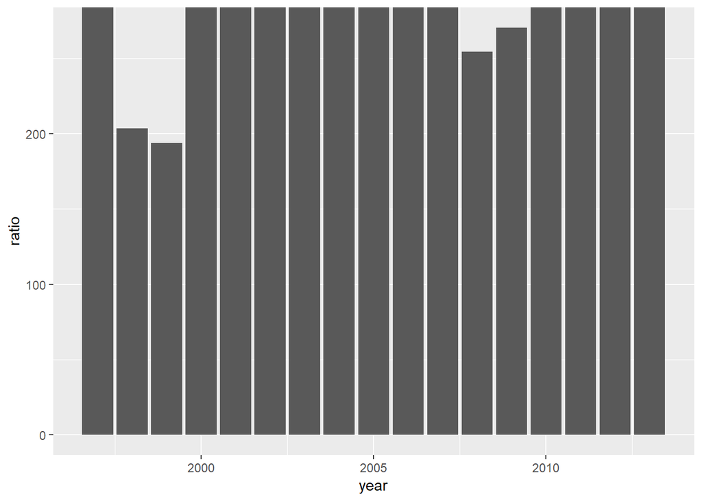

```r
ratio_sex <- ratio_sex %>%
  gather(key=sex,value=total_num,f,m)%>%
  unite(ctr_sex, country, sex)
ggplot(data= ratio_sex, aes(x = year, y = ratio)) + geom_col()
```

# 2 PublicSectorApplication: HomeHealthCareData

## 2.1 Merge Provider Costs with Provider Case-Mix

1. inner_join() command returns all rows from x where there are matching values in y, and all columns from x and y. If there are multiple matches between x and y, all combination of the matches are returned. The required arguments are x and y, which are the tibbles to join.
2. str_sub will recycle all arguments to be the same length as the longest argument. If any arguments are of length 0, the output will be a zero length character vector. The required argument are “string”, “start” and “end”.  
   str_trim() removes whitespace from start and end of string.
3. The ﬁve types of information that are available in both datasets include : episode, therapy visits, clinical severity level, functional severity level and service severity level. Episode describes during which episode a patient visits the agency. Therapy visits describe the number of visits in an episode. Clinical, functional and service severity level all describes how severe the disease of a patient is.

```r
provider_hhrg <- read_xlsx("D:\\R\\dataset\\HH PUF - Provider by HHRG 2014.xlsx",sheet = 3,na="*")
case_mix_weight <- read_csv("D:\\R\\dataset\\CY 2014 Final HH PPS Case-Mix Weights.csv")
colnames(case_mix_weight)[5] <- "weights_2014"
case_mix_weight[,4] <- NULL
View(provider_hhrg)
View(case_mix_weight)
```

4. I plan to use “HHRG Description”. 148 distinct HHRG groups are there using this column.

```r
provider_hhrg %>%
  select(HHRG, `HHRG Description`) %>%
  group_by(`HHRG`) %>%
  n_distinct()
```

```
## [1] 148
```

5. A warning appears because there are extra “,” in these cells. It doesn’t make sense to drop these rows because they contains useful information and we only need to modify them into correct form to employ them.

```r
provider_hhrg<-
  provider_hhrg %>%
  separate(col = `HHRG Description`, into = c("episode", "visit", "cli_level", "fuc_level", "ser_level"), sep = ",",extra = "warn",remove = FALSE, fill = "warn",convert = FALSE)
```

```
## Warning: Expected 5 pieces. Additional pieces discarded in 298 rows [219,
## 965, 1607, 2121, 2201, 4601, 13819, 16783, 17072, 17224, 17312, 18086,
## 18253, 18369, 18409, 18550, 18787, 18921, 19150, 19171, ...].
```

```r
filter(provider_hhrg, row_number() == 219)
```

```
## # A tibble: 1 x 25
##   `Provider ID` `Agency Name` `Street Address` City  State `Zip Code` HHRG
##           <dbl> <chr>         <chr>            <chr> <chr> <chr>      <chr>
## 1         17018 GENTIVA HEAL~ 3225 RAINBOW ST~ RAIN~ AL    35906      4AGL
## # ... with 18 more variables: `HHRG Description` <chr>, episode <chr>,
## #   visit <chr>, cli_level <chr>, fuc_level <chr>, ser_level <chr>, `Total
## #   Episodes` <dbl>, `Distinct Beneficiaries` <dbl>, `Average Number of
## #   Total Visits Per Episode` <dbl>, `Average Number of Skilled Nursing
## #   Visits` <dbl>, `Average Number of PT Visits` <dbl>, `Average Number of
## #   OT Visits` <dbl>, `Average Number of ST Visits` <dbl>, `Average Number
## #   of HH Aide Visits` <dbl>, `Average Number of Medical-Social
## #   Visits` <dbl>, `Average HHA Charge Amount` <dbl>, `Average HHA
## #   Medicare Payment Amount` <dbl>, `Average HHA Medicare Standard Payment
## #   Amount` <dbl>
```

```r
filter(provider_hhrg, row_number() == 695)
```

```
## # A tibble: 1 x 25
##   `Provider ID` `Agency Name` `Street Address` City  State `Zip Code` HHRG
##           <dbl> <chr>         <chr>            <chr> <chr> <chr>      <chr>
## 1         17053 CARESOUTH HO~ 205 GRACELAND D~ DOTH~ AL    36305      5CGK
## # ... with 18 more variables: `HHRG Description` <chr>, episode <chr>,
## #   visit <chr>, cli_level <chr>, fuc_level <chr>, ser_level <chr>, `Total
## #   Episodes` <dbl>, `Distinct Beneficiaries` <dbl>, `Average Number of
## #   Total Visits Per Episode` <dbl>, `Average Number of Skilled Nursing
## #   Visits` <dbl>, `Average Number of PT Visits` <dbl>, `Average Number of
## #   OT Visits` <dbl>, `Average Number of ST Visits` <dbl>, `Average Number
## #   of HH Aide Visits` <dbl>, `Average Number of Medical-Social
## #   Visits` <dbl>, `Average HHA Charge Amount` <dbl>, `Average HHA
## #   Medicare Payment Amount` <dbl>, `Average HHA Medicare Standard Payment
## #   Amount` <dbl>
```

```r
filter(provider_hhrg, row_number() == 1607)
```

```
## # A tibble: 1 x 25
##   `Provider ID` `Agency Name` `Street Address` City  State `Zip Code` HHRG
##           <dbl> <chr>         <chr>            <chr> <chr> <chr>      <chr>
## 1         17143 D W MCMILLAN~ 114 W JACKSON S~ BREW~ AL    36426      4AGL
## # ... with 18 more variables: `HHRG Description` <chr>, episode <chr>,
## #   visit <chr>, cli_level <chr>, fuc_level <chr>, ser_level <chr>, `Total
## #   Episodes` <dbl>, `Distinct Beneficiaries` <dbl>, `Average Number of
## #   Total Visits Per Episode` <dbl>, `Average Number of Skilled Nursing
## #   Visits` <dbl>, `Average Number of PT Visits` <dbl>, `Average Number of
## #   OT Visits` <dbl>, `Average Number of ST Visits` <dbl>, `Average Number
## #   of HH Aide Visits` <dbl>, `Average Number of Medical-Social
## #   Visits` <dbl>, `Average HHA Charge Amount` <dbl>, `Average HHA
## #   Medicare Payment Amount` <dbl>, `Average HHA Medicare Standard Payment
## #   Amount` <dbl>
```

```r
provider_hhrg <-
  provider_hhrg %>%
  mutate(cli_level_l = str_sub(str_trim(cli_level), 1,1), cli_level_r = str_sub(str_trim(cli_level),-1,-1),
         fuc_level_l = str_sub(str_trim(fuc_level), 1,1), fuc_level_r = str_sub(str_trim(fuc_level),-1,-1),
         ser_level_l = str_sub(str_trim(ser_level), 1,1), ser_level_r = str_sub(str_trim(ser_level),-1,-1),
         episode = str_trim(episode),
         visit = str_trim(visit)) %>%
  unite(cli_level,cli_level_l,cli_level_r,sep = "") %>%
  unite(fuc_level,fuc_level_l,fuc_level_r,sep = "") %>%
  unite(ser_level,ser_level_l,ser_level_r,sep = "")

drops <- c("cli_level_l","cli_level_r","fuc_level_l","fuc_level_r", "ser_level_l", "ser_level_r")
provider_hhrg[ , !(names(provider_hhrg) %in% drops)]
```

```
## # A tibble: 104,920 x 25
##    `Provider ID` `Agency Name` `Street Address` City  State `Zip Code`
##            <dbl> <chr>         <chr>            <chr> <chr> <chr>
##  1         17009 ALACARE HOME~ 2970 LORNA ROAD  BIRM~ AL    35216
##  2         17009 ALACARE HOME~ 2970 LORNA ROAD  BIRM~ AL    35216
##  3         17009 ALACARE HOME~ 2970 LORNA ROAD  BIRM~ AL    35216
##  4         17009 ALACARE HOME~ 2970 LORNA ROAD  BIRM~ AL    35216
##  5         17009 ALACARE HOME~ 2970 LORNA ROAD  BIRM~ AL    35216
##  6         17009 ALACARE HOME~ 2970 LORNA ROAD  BIRM~ AL    35216
##  7         17009 ALACARE HOME~ 2970 LORNA ROAD  BIRM~ AL    35216
##  8         17009 ALACARE HOME~ 2970 LORNA ROAD  BIRM~ AL    35216
##  9         17009 ALACARE HOME~ 2970 LORNA ROAD  BIRM~ AL    35216
## 10         17009 ALACARE HOME~ 2970 LORNA ROAD  BIRM~ AL    35216
## # ... with 104,910 more rows, and 19 more variables: HHRG <chr>, `HHRG
## #   Description` <chr>, episode <chr>, visit <chr>, `Total
## #   Episodes` <dbl>, `Distinct Beneficiaries` <dbl>, `Average Number of
## #   Total Visits Per Episode` <dbl>, `Average Number of Skilled Nursing
## #   Visits` <dbl>, `Average Number of PT Visits` <dbl>, `Average Number of
## #   OT Visits` <dbl>, `Average Number of ST Visits` <dbl>, `Average Number
## #   of HH Aide Visits` <dbl>, `Average Number of Medical-Social
## #   Visits` <dbl>, `Average HHA Charge Amount` <dbl>, `Average HHA
## #   Medicare Payment Amount` <dbl>, `Average HHA Medicare Standard Payment
## #   Amount` <dbl>, cli_level <chr>, fuc_level <chr>, ser_level <chr>
```

6. In case_mix_weight I plan to use “Description” and “Clinical, Functional, and Service Levels” for merging. 153 HHRG groups are there using these columns.

```r
case_mix_weight <-
  case_mix_weight %>%
  separate(col=Description,into=c("episode","visit"),sep=",",extra = "warn",remove = FALSE, fill = "warn",convert = FALSE) %>%
  separate(col=`Clinical, Functional, and Service Levels`,into = c("cli_level","fuc_level","ser_level"), sep = c(2,4))
```

```r
case_mix_weight <-
  case_mix_weight %>%
  mutate(visit = fct_collapse(str_trim(visit),
        "0-13 therapies" = c("0 to 5 Therapy Visits","6 Therapy Visits","7 to 9 Therapy Visits","10 Therapy Visits","11 to 13 Therapy Visits"),
        "14-19 therapies" = c("14 to 15 Therapy Visits","16 to 17 Therapy Visits","18 to 19 Therapy Visits"),
        "20+ therapies" = c("20+ Therapy Visits")))

case_mix_weight <-
  case_mix_weight %>%
  mutate(episode = fct_recode(episode,
                        "Early Episode" = "1st and 2nd Episodes",
                        "Early or Late Episode" = "All Episodes",
                        "Late Episode" = "3rd+ Episodes"))
```

```r
provider_hhrg_wt <-
  inner_join(provider_hhrg, case_mix_weight, by = c("episode", "visit", "cli_level", "fuc_level", "ser_level"))
provider_hhrg_wt
```

```
## # A tibble: 104,920 x 28
##    `Provider ID` `Agency Name` `Street Address` City  State `Zip Code`
##            <dbl> <chr>         <chr>            <chr> <chr> <chr>
##  1         17009 ALACARE HOME~ 2970 LORNA ROAD  BIRM~ AL    35216
##  2         17009 ALACARE HOME~ 2970 LORNA ROAD  BIRM~ AL    35216
##  3         17009 ALACARE HOME~ 2970 LORNA ROAD  BIRM~ AL    35216
##  4         17009 ALACARE HOME~ 2970 LORNA ROAD  BIRM~ AL    35216
##  5         17009 ALACARE HOME~ 2970 LORNA ROAD  BIRM~ AL    35216
##  6         17009 ALACARE HOME~ 2970 LORNA ROAD  BIRM~ AL    35216
##  7         17009 ALACARE HOME~ 2970 LORNA ROAD  BIRM~ AL    35216
##  8         17009 ALACARE HOME~ 2970 LORNA ROAD  BIRM~ AL    35216
##  9         17009 ALACARE HOME~ 2970 LORNA ROAD  BIRM~ AL    35216
## 10         17009 ALACARE HOME~ 2970 LORNA ROAD  BIRM~ AL    35216
## # ... with 104,910 more rows, and 22 more variables: HHRG <chr>, `HHRG
## #   Description` <chr>, episode <chr>, visit <chr>, `Total
## #   Episodes` <dbl>, `Distinct Beneficiaries` <dbl>, `Average Number of
## #   Total Visits Per Episode` <dbl>, `Average Number of Skilled Nursing
## #   Visits` <dbl>, `Average Number of PT Visits` <dbl>, `Average Number of
## #   OT Visits` <dbl>, `Average Number of ST Visits` <dbl>, `Average Number
## #   of HH Aide Visits` <dbl>, `Average Number of Medical-Social
## #   Visits` <dbl>, `Average HHA Charge Amount` <dbl>, `Average HHA
## #   Medicare Payment Amount` <dbl>, `Average HHA Medicare Standard Payment
## #   Amount` <dbl>, cli_level <chr>, fuc_level <chr>, ser_level <chr>,
## #   `Payment group` <int>, Description <chr>, weights_2014 <dbl>
```

```r
test_that("we have the right number of rows",expect_equal(nrow(provider_hhrg_wt),104920))
count(provider_hhrg_wt, is.na(weights_2014))
```

```
## # A tibble: 1 x 2
##   `is.na(weights_2014)`      n
##   <lgl>                  <int>
## 1 FALSE                 104920
```

10. The warning is “Column `episode` joining character vector and factor, coercing into character vectorColumn `visit` joining character vector and factor, coercing into character vector”. It means the inner_join() will transformed the different types of variables by which we join the two datasets together into a single type.

## 2.2 Billing Outlier Analysis

```r
#Construct provider_sum
provider_sum <-
  provider_hhrg_wt %>%
  group_by(`Provider ID`) %>%
  summarise(`Agency Name` = unique(`Agency Name`),
            State = unique(State),
            mean_pay_wt_ep = weighted.mean(`Average HHA Medicare Payment Amount`, `Total Episodes`),
            mean_pay_wt_ca = weighted.mean(`Average HHA Medicare Payment Amount`, weights_2014),
            c_mix_wtmean = weighted.mean(weights_2014, `Total Episodes`),
            n_total_epi = sum(`Total Episodes`))
```

1. The average cost varies more in higher range and there are only outliers of high cost and no outliers of low cost.

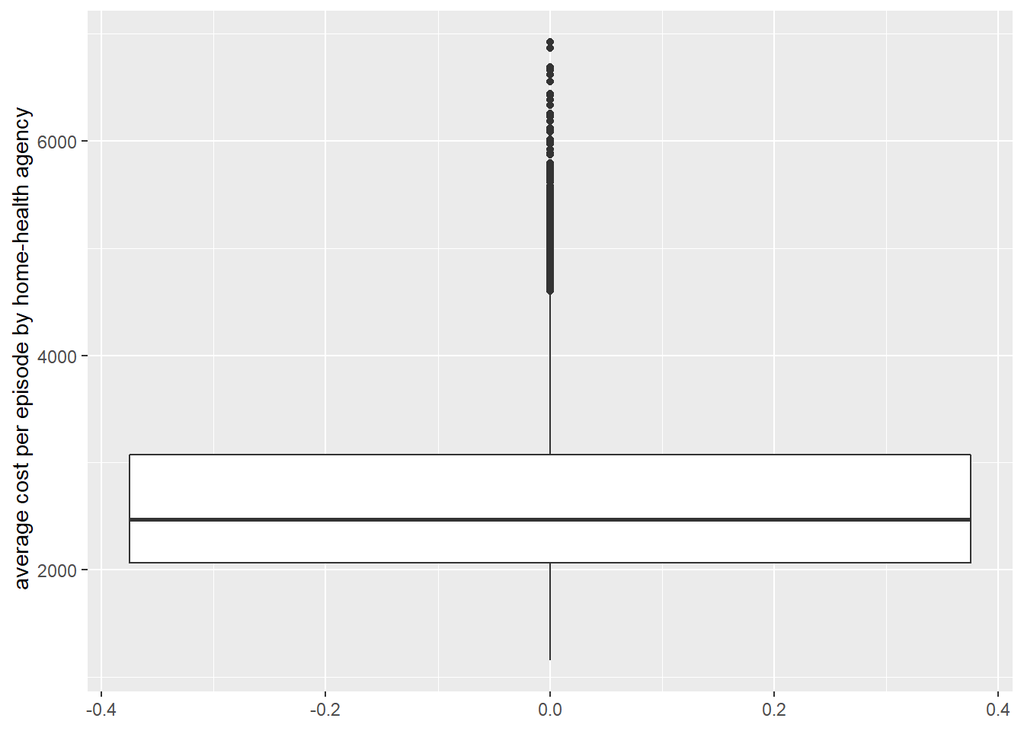

```r
ggplot(provider_sum, aes(y = mean_pay_wt_ep)) +
  geom_boxplot() +
  ylab(" average cost per episode by home-health agency")
```

2. The outliers of average cost after accounting for case-mix weight locate more densely.

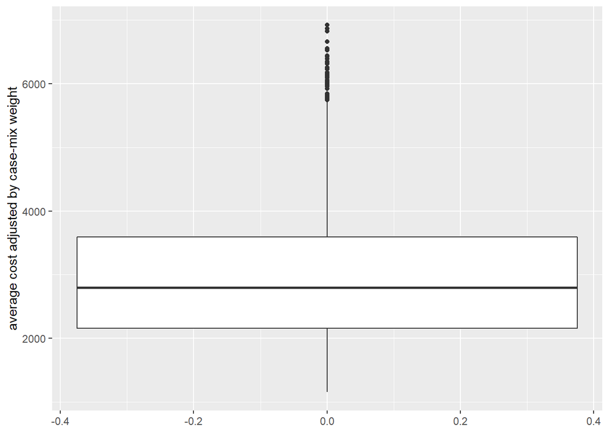

```r
ggplot(provider_sum, aes(y = mean_pay_wt_ca)) +
  geom_boxplot() +
  ylab("average cost adjusted by case-mix weight")
```

3. The red histogram is average cost per episode across HHAs and the blue histogram is the normalized average cost adjusted by case-mix. We can see that the dispersion of cost has been reduced after normalization.

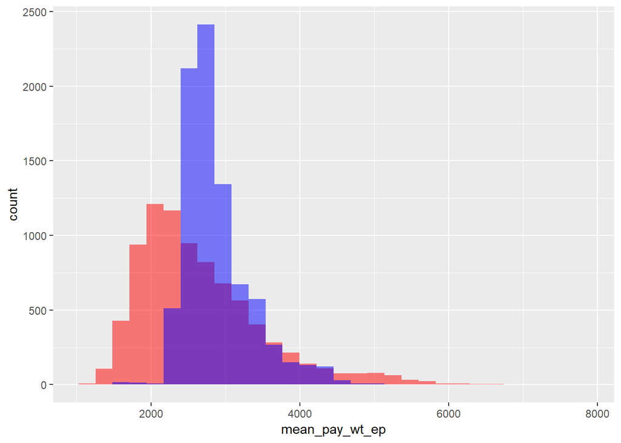

```r
provider_sum <-
  provider_sum %>%
  mutate(cost_normalized = mean_pay_wt_ep / c_mix_wtmean)

ggplot(data = provider_sum) +
    geom_histogram(mapping = aes(x = mean_pay_wt_ep), fill = "red", alpha = 0.5) +
    geom_histogram(mapping = aes(x = cost_normalized), fill = "blue", alpha = 0.5)
```

```r
#https://stackoverflow.com/questions/6957549/overlaying-histograms-with-ggplot2-in-r
```

4. The top 5 HHAs with the highest billing per episode in Illinois are: PRIME CARE RESOURCE, INC, FORUM HEALTH CARE, SIMPLY HOME HEALTH, LLC, HOME BOUND HEALTHCARE, INC and WHITESTAR HOME HEALTH INC.  
   The top 5 HHAs with the highest markups are : FAIRFIELD MEMORIAL HOSPITAL, HENDERSON COUNTY HEALTH DEPART, BEST CARE HOME HEALTH, INC., QUANTUM HEALTHCARE SERVICES, INC and SWEDISH COVENANT HOSPITAL HOME. There isn’t any overlapping in these two lists.

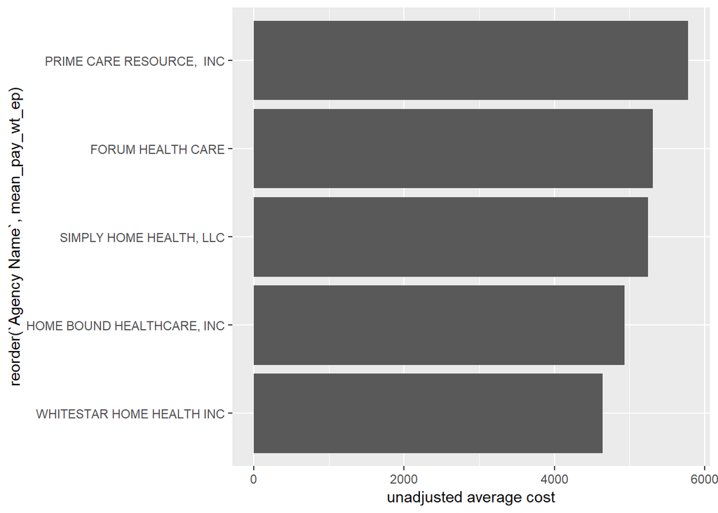

```r
top5_unadj <-
  provider_sum %>%
  filter(State == "IL") %>%
  arrange(desc(mean_pay_wt_ep)) %>%
  slice(1:5)

ggplot(top5_unadj, aes(x = reorder(`Agency Name`, mean_pay_wt_ep), y = mean_pay_wt_ep)) +
  geom_col() +
  ylab("unadjusted average cost") +
  coord_flip()
```

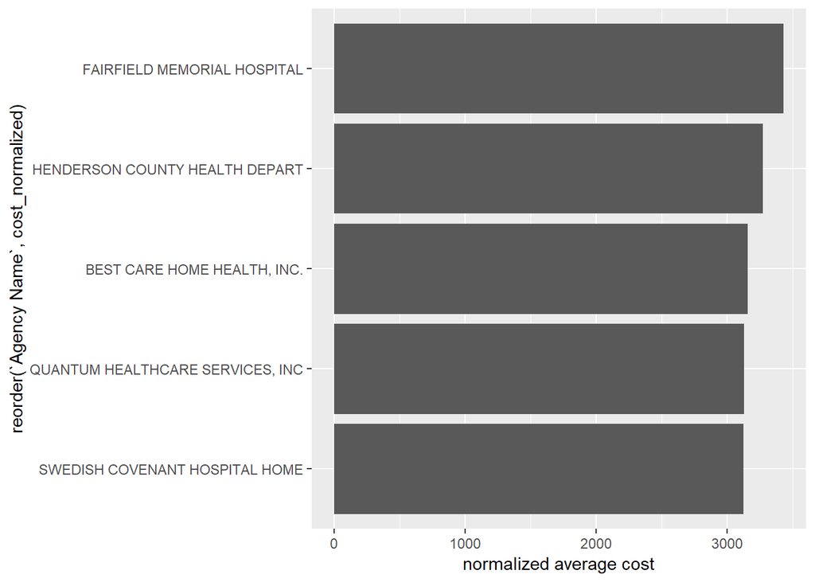

```r
top5_norm <-
  provider_sum %>%
  filter(State == "IL") %>%
  arrange(desc(cost_normalized)) %>%
  slice(1:5)

ggplot(top5_norm, aes(x = reorder(`Agency Name`, cost_normalized), y = cost_normalized)) +
  geom_col() +
  ylab("normalized average cost") +
  coord_flip()
```